Sarah de Vegvar Lab 2

Choose a spatial dataset. It could be one in a data package from your text, or one that’s already been prepared and made available through an open data portal or GeoDa’s practice data sets, etc. Your final dataset should be loaded as a spatial data frame using the sf package in R.

I am using the world dataset from the spData package.

```r
library(sf)
library(raster)
library(dplyr)
library(stringr) # for working with strings (pattern matching)
library(tidyr)   # for unite() and separate()
library(spData)
```

1. Provide summary statistics for key variables in your spatial dataset. You can use any tutorial or R-practical of your choice for additional resources.

I found that summary statistics for the life expectancy of the world dataset

```r
summary(world$lifeExp)
```

```
##    Min. 1st Qu.  Median    Mean 3rd Qu.    Max.    NA's
##   50.62   64.96   72.87   70.85   76.78   83.59      10
```

2. Generate a (non-spatial) plot or figure of the variable of interest using your method of preference (histogram, violin plot, etc). You can use any tutorial or R-practical of your choice for additional resources.

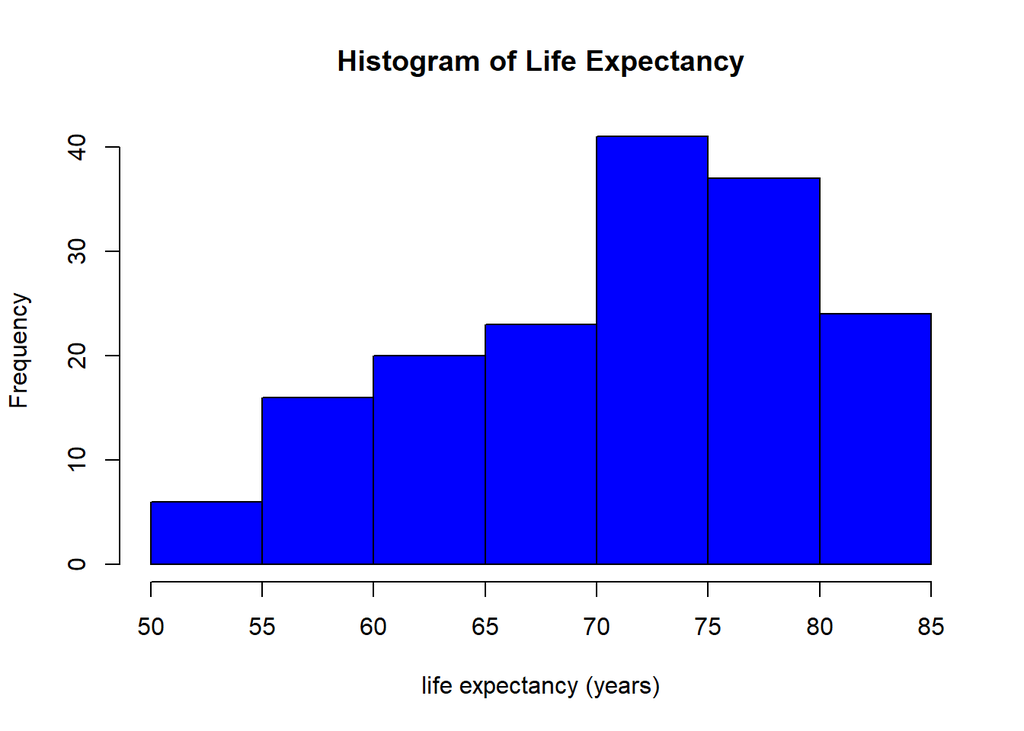

```r
hist(world$lifeExp, col = 'blue', main = "Histogram of Life Expectancy", xlab = "life expectancy (years)")
```

```r
summarize(world)
```

```
## Simple feature collection with 1 feature and 0 fields
## geometry type:  MULTIPOLYGON
## dimension:      XY
## bbox:           xmin: -180 ymin: -90 xmax: 180 ymax: 83.64513
## CRS:            EPSG:4326
## # A tibble: 1 x 1
##                                                                             geom
##                                                               <MULTIPOLYGON [°]>
## 1 (((-163.7129 -78.59567, -163.7129 -78.59567, -163.1058 -78.22334, -161.2451 -~
```

3. Map the variable of interest in R.

```r
names(world)
```

```
##  [1] "iso_a2"    "name_long" "continent" "region_un" "subregion" "type"
##  [7] "area_km2"  "pop"       "lifeExp"   "gdpPercap" "geom"
```

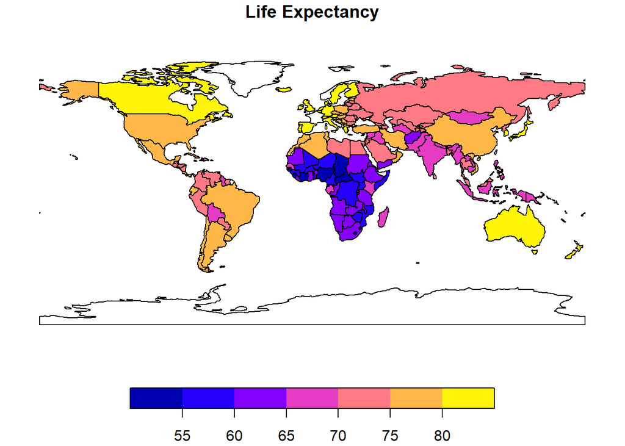

```r
plot(world["lifeExp"], main ="Life Expectancy")
```

4. Use Rmarkdown to generate a short, cohesive report. Include a title, authorship, appropriate formatting, and brief descriptions to introduce and provide context for the code you generate. The data you used should be cited.